# **PCFL 2022: Week 10 wrap-up**

Hey all! We’ve got just five weeks to go in the regular season. Fantasy life moves fast.

## Last week’s games

| Winner | Winner’s score | Loser | Loser’s score |
| --- | --- | --- | --- |
| Georgia Peanuts | 115.60 | Athens Team Sasquatch | 95.40 |
| The Juniors | 122.94 | Middle Earth Hangry Hobbits | 120.80 |
| The G.O.A.T. | 95.60 | Jumpin’ Jaheims | 88.81 |
| KC Gophers | 108.58 | Southern Sharks | 98.14 |
| Captain Clairvoyant | 97.90 | Pigskin on the Gridiron | 89.72 |

The top game last week was The Juniors versus the Hobbits, a purely Minnesota battle. It was a high scoring affair between the two top point-scorers this week, but Erin and Trav came out on top in the end.

## Best performances

### Best players overall

Here’s last week’s **10 best performing starters.**

| Player | Position | NFL Team | Points | PCFL Team |
| --- | --- | --- | --- | --- |
| CeeDee Lamb | WR | DAL | 32.50 | KC Gophers |
| Patrick Mahomes | QB | KCC | 31.14 | Southern Sharks |
| Justin Jefferson | WR | MIN | 30.30 | Middle Earth Hangry Hobbits |
| Christian Kirk | WR | JAC | 27.00 | Athens Team Sasquatch |
| Davante Adams | WR | OAK | 24.10 | The G.O.A.T. |
| Tua Tagovailoa | QB | MIA | 23.40 | Middle Earth Hangry Hobbits |
| Jonathan Taylor | RB | IND | 23.30 | KC Gophers |
| Saquon Barkley | RB | NYG | 22.50 | The G.O.A.T. |
| Cole Kmet | TE | CHI | 22.40 | The Juniors |
| Dalvin Cook | RB | MIN | 22.10 | Captain Clairvoyant |
| James Conner | RB | ARI | 22.10 | Pigskin on the Gridiron |

Nice week for several wide receivers.

### Best players per team

Here’s last week’s top players **on each team.**

| Player | Position | NFL Team | Points | PCFL Team |
| --- | --- | --- | --- | --- |
| Christian Kirk | WR | JAC | 27.00 | Athens Team Sasquatch |
| Dalvin Cook | RB | MIN | 22.10 | Captain Clairvoyant |
| Justin Fields | BE | CHI | 39.38 | Georgia Peanuts |
| Aaron Jones | BE | GBP | 22.60 | Jumpin’ Jaheims |
| CeeDee Lamb | WR | DAL | 32.50 | KC Gophers |
| Justin Jefferson | WR | MIN | 30.30 | Middle Earth Hangry Hobbits |
| James Conner | RB | ARI | 22.10 | Pigskin on the Gridiron |
| Patrick Mahomes | QB | KCC | 31.14 | Southern Sharks |
| Davante Adams | WR | OAK | 24.10 | The G.O.A.T. |
| Cole Kmet | TE | CHI | 22.40 | The Juniors |

### Best bench

Who won the **best scoring bench** award last week?

| Team | Bench points |
| --- | --- |
| Georgia Peanuts | 65.63 |
| Athens Team Sasquatch | 60.38 |
| Jumpin’ Jaheims | 56.70 |
| KC Gophers | 49.70 |
| Pigskin on the Gridiron | 48.68 |
| Middle Earth Hangry Hobbits | 31.74 |
| The G.O.A.T. | 24.80 |
| Southern Sharks | 23.86 |
| Captain Clairvoyant | 23.60 |
| The Juniors | 18.90 |

Hurray for the Peanuts!

Here’s the season’s bench standings:

| Team | Bench points |
| --- | --- |
| Middle Earth Hangry Hobbits | 616.45 |
| Jumpin’ Jaheims | 612.98 |
| The G.O.A.T. | 604.60 |
| KC Gophers | 583.95 |
| Georgia Peanuts | 477.55 |
| Southern Sharks | 463.60 |
| Pigskin on the Gridiron | 460.57 |
| Athens Team Sasquatch | 454.79 |
| The Juniors | 417.44 |
| Captain Clairvoyant | 369.20 |

Scott’s still in the lead here.

### Best optimized lineups

I compared the actual starting lineups for each team to the hypothetical *best* starting lineup the owner could have started. The table below shows the actual points the team scored, the top score they could have had, and an “optimization” percentage that compares to the two.

| PCFL Team | Actual points | Best lineup | Optimization rate |
| --- | --- | --- | --- |
| The Juniors | 122.94 | 122.94 | 100% |
| Southern Sharks | 98.14 | 103.14 | 95% |
| Middle Earth Hangry Hobbits | 120.80 | 131.90 | 92% |
| Athens Team Sasquatch | 95.40 | 104.60 | 91% |
| Captain Clairvoyant | 97.90 | 109.60 | 89% |
| Georgia Peanuts | 115.60 | 133.18 | 87% |
| The G.O.A.T. | 95.60 | 112.30 | 85% |
| Pigskin on the Gridiron | 89.72 | 106.78 | 84% |
| KC Gophers | 108.58 | 134.88 | 81% |
| Jumpin’ Jaheims | 88.81 | 123.56 | 72% |

For the *whole season*, here’s a graph of actual points scored vs. optimized points given the roster.

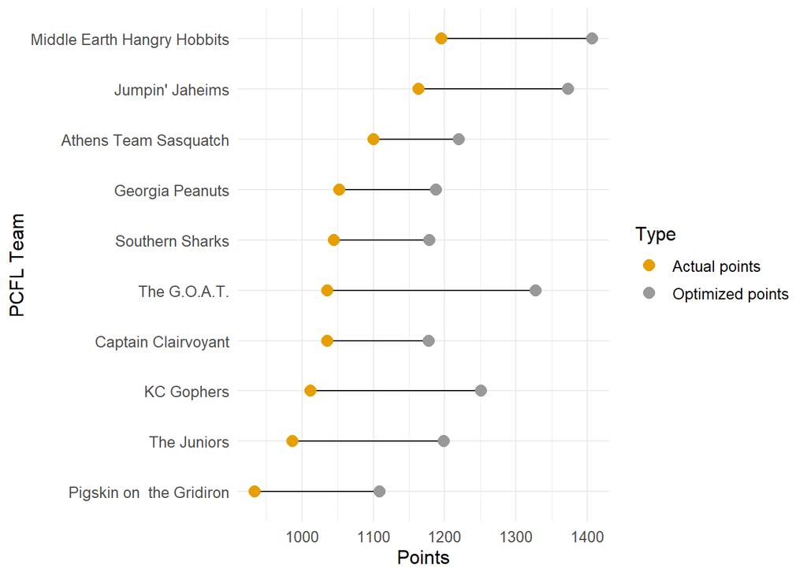

Still Scott and Evan at the top for both actual and optimized points, but both have left a lot on the table. Jacob’s gap remains the largest.

### Best additions

There were 11 players added last week. Which was the **best new addition**?

| PCFL Team | Player | NFL Team | Position | Points |
| --- | --- | --- | --- | --- |
| Georgia Peanuts | Jeff Wilson Jr. | MIA | RB | 21.30 |
| Athens Team Sasquatch | Jacoby Brissett | CLE | QB | 16.48 |
| Captain Clairvoyant | Jimmy Garoppolo | SFO | QB | 15.90 |
| Athens Team Sasquatch | Brian Robinson Jr. | WAS | RB | 14.60 |
| Captain Clairvoyant | Dalton Schultz | DAL | TE | 14.40 |
| KC Gophers | Tyler Higbee | LAR | TE | 11.30 |
| Athens Team Sasquatch | Titans D/ST | TEN | DST | 11.00 |
| KC Gophers | Robbie Gould | SFO | K | 10.00 |
| The Juniors | Graham Gano | NYG | K | 7.00 |
| Georgia Peanuts | Cairo Santos | CHI | K | 6.00 |
| Jumpin’ Jaheims | Falcons D/ST | ATL | DST | 1.00 |

The bye weeks mean lots of quarterbacks and tight ends on the waiver wire. None did particularly well, though Dalton Schultz was respectable for Brian.

### Best team performances

Here’s a list of the **top five scoring performances** so far this season.

| PCFL Team | Week | Score | Result |
| --- | --- | --- | --- |
| Athens Team Sasquatch | 8 | 153.85 | W |
| Southern Sharks | 9 | 151.24 | W |
| Southern Sharks | 8 | 150.26 | L |
| Middle Earth Hangry Hobbits | 1 | 148.06 | W |
| Georgia Peanuts | 2 | 147.22 | W |

No changes this week.

## Looking ahead

### League standings

| PCFL Team | Division | Points scored | Avg points | Avg last 3 | W | L | Team points |
| --- | --- | --- | --- | --- | --- | --- | --- |
| Middle Earth Hangry Hobbits | Hot Dish | 1195.04 | 119.50 | 120.50 | 6 | 4 | 14 |
| Jumpin’ Jaheims | Grits | 1145.33 | 114.53 | 97.28 | 8 | 2 | 14 |
| Athens Team Sasquatch | Grits | 1100.05 | 110.00 | 112.09 | 6 | 4 | 12 |
| Georgia Peanuts | Hot Dish | 1052.34 | 105.23 | 117.86 | 5 | 5 | 10 |
| KC Gophers | Hot Dish | 1011.54 | 101.15 | 89.21 | 5 | 5 | 10 |
| The Juniors | Hot Dish | 987.07 | 98.71 | 116.73 | 6 | 4 | 10 |
| The G.O.A.T. | Grits | 1035.88 | 103.59 | 102.27 | 4 | 6 | 9 |
| Captain Clairvoyant | Grits | 1035.60 | 103.56 | 96.41 | 5 | 5 | 9 |
| Southern Sharks | Hot Dish | 1044.78 | 104.48 | 133.21 | 2 | 8 | 6 |
| Pigskin on the Gridiron | Grits | 933.38 | 93.34 | 89.09 | 3 | 7 | 6 |

Scott and Evan are now tied for tops in the leagu, with Robbie solidly in third. It’s a three team tie for the fourth spot (me, Crissy, and Erin/Trav). Sarah and Richard are now fighting it for the toilet trophy.

### If the season ended today…

Here’s our playoff picture right now: * Division winners: Evan (14 points, Grits), and Scott (14 points, Hot Dish). * Wild cards: Robbie (12 points) and me (10 points and a points scored tie breaker)

The ESPN version would still be Evan and Scott as division winners, but the wildcards would be Robbie and Erin/Trav based on wins.

****If you have concerns about this system, let me know ASAP****

### Next week’s matchups

| Team 1 | Team 2 |
| --- | --- |
| Athens Team Sasquatch (Avg. last 3: 112.09) | Pigskin on the Gridiron (Avg. last 3: 89.09) |
| Captain Clairvoyant (Avg. last 3: 96.41) | The G.O.A.T. (Avg. last 3: 102.27) |
| Georgia Peanuts (Avg. last 3: 117.86) | Middle Earth Hangry Hobbits (Avg. last 3: 120.5) |
| Jumpin’ Jaheims (Avg. last 3: 97.28) | KC Gophers (Avg. last 3: 89.21) |
| Southern Sharks (Avg. last 3: 133.21) | The Juniors (Avg. last 3: 116.73) |

It’s a family battle this week between Sarah and Erin (and Trav), as the sisters face off in what may be a high scoring battle. Evan tries to break his team slump against Crissy. Brian tries to get into the playoff picture against Jacob and Richard does the same against Robbie. Lastly, my running back situation is dire, but I’ll do my best against our points leader, Scott.

Good luck, y’all! (And check your byes!)